# Assignment 1

Nathanael Reese

2023-02-03

# Problems Complete 2/15

# Problem 1

**Assignment Weights**

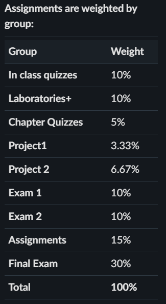

**Final Grade**

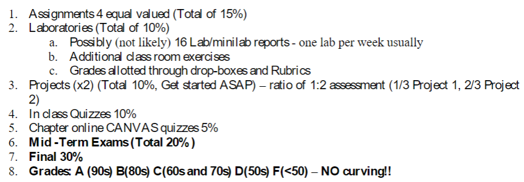

# Problem 2

```r
ddt = read.csv("DDT.csv")
head(ddt)
```

```
##   RIVER MILE  SPECIES LENGTH WEIGHT DDT
## 1   FCM    5 CCATFISH   42.5    732  10
## 2   FCM    5 CCATFISH   44.0    795  16
## 3   FCM    5 CCATFISH   41.5    547  23
## 4   FCM    5 CCATFISH   39.0    465  21
## 5   FCM    5 CCATFISH   50.5   1252  50
## 6   FCM    5 CCATFISH   52.0   1255 150
```

```r
m=with(ddt, as.numeric(factor(MILE))) # A
length(unique(m))
```

```
## [1] 17
```

```r
getmode <- function(v) {
   uniqv <- unique(v)
   uniqv[which.max(tabulate(match(v, uniqv)))]
}
```

### a)

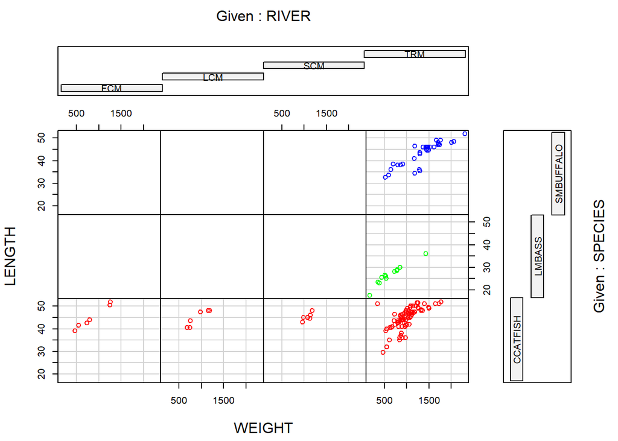

```r
fishcol=with(ddt,ifelse(SPECIES=="CCATFISH","Red",
                        ifelse(SPECIES=="SMBUFFALO","Blue","Green")))

#River col
rivcol=with(ddt, ifelse(RIVER=="FCM","Red",
                        ifelse(RIVER=="LCM","Blue",
                               ifelse(RIVER=="SCM","Green","Black"))))

coplot(LENGTH~WEIGHT|RIVER*SPECIES,data=ddt,col=fishcol)
```

### b)

- The lower left three plots are showing specific fish with the species of CCATFISH in the riversFCM, LCM, and SCM with their length(y-axis) and weight(x-axis)

### c)

**Line A** Line A creates a numeric vector (vector in numeric order) of all of the mile values in ddt and stores it in variable m `m=with(ddt, as.numeric(factor(MILE)))`

### d)

**Line B** Line B returns the number of unique values in vector m given in line A `length(unique(m))`

### e)

`There are no LMBASS or SMBUFFALO in rivers FCM, LCM, or SCM as shown below.`

```r
ddt[ddt$RIVER=="FCM" & ddt$SPECIES=="LMBASS",]
```

```
## [1] RIVER   MILE    SPECIES LENGTH  WEIGHT  DDT
## <0 rows> (or 0-length row.names)
```

```r
ddt[ddt$RIVER=="FCM" & ddt$SPECIES=="SMBUFFALO",]
```

```
## [1] RIVER   MILE    SPECIES LENGTH  WEIGHT  DDT
## <0 rows> (or 0-length row.names)
```

```r
ddt[ddt$RIVER=="LCM" & ddt$SPECIES=="LMBASS",]
```

```
## [1] RIVER   MILE    SPECIES LENGTH  WEIGHT  DDT
## <0 rows> (or 0-length row.names)
```

```r
ddt[ddt$RIVER=="LCM" & ddt$SPECIES=="SMBUFFALO",]
```

```
## [1] RIVER   MILE    SPECIES LENGTH  WEIGHT  DDT
## <0 rows> (or 0-length row.names)
```

```r
ddt[ddt$RIVER=="SCM" & ddt$SPECIES=="LMBASS",]
```

```
## [1] RIVER   MILE    SPECIES LENGTH  WEIGHT  DDT
## <0 rows> (or 0-length row.names)
```

```r
ddt[ddt$RIVER=="SCM" & ddt$SPECIES=="SMBUFFALO",]
```

```
## [1] RIVER   MILE    SPECIES LENGTH  WEIGHT  DDT
## <0 rows> (or 0-length row.names)
```

### f)

```r
catfish=ddt[ddt$RIVER=="FCM" & ddt$SPECIES=="CCATFISH",]
mean(catfish$DDT)
```

```
## [1] 45
```

# Problem 3

### a)

**Quantitative**

### b)

**Quantitative**

### c)

**Qualitative**

### d)

**Quantitative**

### e)

**Qualitative**

### f)

**Quantitative**

### g)

**Qualitative**

# Problem 4

### a)

**sampling without replacement, stratified random sampling, cluster sampling, and systematic sampling.**

### b)

- Sampling Without Replacement - you select a number that has been previously selected, simply discard the duplicate and select a replacement at the end of the sequence.
- Stratified Random Sampling - Random samples of experimental units are obtained for each strata, then the units are combined to form the complete sample.
- Cluster Sampling - Rather than collect a simple random sample of all lines of code in the 150 programs (which would be very difficult and costly to do), the engineer will randomly sample 10 of the 150 programs (clusters), then examine all lines of code in each sampled program.
- Systematic Sampling - This method involves systematically selecting every kth experimental unit from a list of all experimental units.

# Problem 5

```r
mtbe=read.csv("MTBE.csv", header=TRUE) # You will need to change the address
head(mtbe) # First six lines
```

```
##     pH SpConduct DissOxy RoadsPct IndPct UrbanPct DevPct WellClass Aquifier
## 1 7.87     290.0    0.58     1.34      0    17.77  17.77   Private  Bedrock
## 2 8.63     225.9    0.84     0.72      0    10.43  10.43   Private  Bedrock
## 3 7.11     157.4    8.37     1.92      0    29.62  50.01   Private  Bedrock
## 4 7.98     723.6    0.41     2.76      0    41.65  41.65   Private  Bedrock
## 5 7.88     148.7    1.44     3.51      0    51.21  51.21   Private  Bedrock
## 6 8.36     198.2    0.18     1.48      0    22.49  29.19   Private  Bedrock
##     Depth SafeYld Distance MTBE.Detect MTBE.Level HouseDen PopDen
## 1  60.960      NA  2386.29 Below Limit        0.2   131.16  43.19
## 2  36.576      NA  3667.69 Below Limit        0.2    47.69  24.52
## 3 152.400      NA  2324.15 Below Limit        0.2    85.16  33.32
## 4      NA      NA   788.88 Below Limit        0.2   134.77  46.61
## 5  91.440      NA  1337.88 Below Limit        0.2   198.54  78.58
## 6 115.824      NA  2396.74 Below Limit        0.2   206.73  59.47
```

```r
dim(mtbe) # rows and columns
```

```
## [1] 223  16
```

```r
ind=sample(1:223,5,replace=FALSE) # random indices
mtbe[ind,]
```

```
##       pH SpConduct DissOxy RoadsPct IndPct UrbanPct DevPct WellClass Aquifier
## 50  8.21     153.9    1.83     2.09   0.24    47.55  65.61   Private  Bedrock
## 118 6.40     527.8    2.14     2.41   0.00    29.03  31.36    Public  Bedrock
## 183 7.78     352.3    4.79     3.17   8.42    25.58  25.58    Public  Bedrock
## 165 5.59     906.7    3.61     1.73   4.84    14.95  14.95    Public  Bedrock
## 197 8.31     208.5    0.59     3.80   0.00    52.14  55.38    Public  Bedrock
##       Depth   SafeYld Distance MTBE.Detect MTBE.Level HouseDen PopDen
## 50   68.580        NA  2154.46 Below Limit       0.20   204.43  63.70
## 118  42.672 264.95080  1945.64      Detect       0.39   221.41  92.23
## 183 182.880  32.17260   333.35      Detect       2.61   141.84  68.93
## 165  76.200  56.77517   265.08      Detect       0.26   142.96  68.64
## 197  91.440  11.35503  1703.94 Below Limit       0.20   706.51 297.05
```

### a)

#### i)

```r
mtbeo=na.omit(mtbe)
```

#### ii)

```r
sd(mtbeo[mtbeo$Aquifier=="Bedrock",]$Depth)
```

```
## [1] 56.45357
```